# EasyVisa_KimAbernathy_FullCodeProject (2)

## Problem Statement

### Business Context

Business communities in the United States are facing high demand for human resources, but one of the constant challenges is identifying and attracting the right talent, which is perhaps the most important element in remaining competitive. Companies in the United States look for hard-working, talented, and qualified individuals both locally as well as abroad.

The Immigration and Nationality Act (INA) of the US permits foreign workers to come to the United States to work on either a temporary or permanent basis. The act also protects US workers against adverse impacts on their wages or working conditions by ensuring US employers' compliance with statutory requirements when they hire foreign workers to fill workforce shortages. The immigration programs are administered by the Office of Foreign Labor Certification (OFLC).

OFLC processes job certification applications for employers seeking to bring foreign workers into the United States and grants certifications in those cases where employers can demonstrate that there are not sufficient US workers available to perform the work at wages that meet or exceed the wage paid for the occupation in the area of intended employment.

### Objective

In FY 2016, the OFLC processed 775,979 employer applications for 1,699,957 positions for temporary and permanent labor certifications. This was a nine percent increase in the overall number of processed applications from the previous year. **The process of reviewing every case is becoming a tedious task as the number of applicants is increasing every year.**

The increasing number of applicants every year calls for a Machine Learning based solution that can help in shortlisting the candidates having higher chances of VISA approval. OFLC has hired the firm EasyVisa for data-driven solutions. You as a data scientist at EasyVisa have to analyze the data provided and, with the help of a **classification model**:

- Facilitate the process of visa approvals.
- Recommend a suitable profile for the applicants for whom the visa should be certified or denied based on the drivers that significantly influence the case status.

### Data Description

**The detailed data dictionary is given below:**

- `case_id`: ID of each visa application
- `continent`: Continent where the employee resides
- `education_of_employee`: Information of education of the employee
- `has_job_experience`: Does the employee have any job experience? Y= Yes; N = No
- `requires_job_training`: Does the employee require any job training? Y = Yes; N = No
- `no_of_employees`: Number of employees in the employer's company
- `yr_of_estab`: Year in which the employer's company was established
- `region_of_employment`: Information of foreign worker's intended region of employment in the US.
- `prevailing_wage`: Average wage paid to similarly employed workers in a specific occupation in the area of intended employment. The purpose of the prevailing wage is to ensure that the foreign worker is not underpaid compared to other workers offering the same or similar service in the same area of employment.
- `unit_of_wage`: Unit of prevailing wage. Values include Hourly, Weekly, Monthly, and Yearly.
- `full_time_position`: Is the position of work full-time? Y = Full Time Position; N = Part Time Position
- `case_status`: Flag indicating if the Visa was certified or denied

## Installing and Importing Necessary Libraries

```python
# Installing the libraries with the specified version.
!pip install numpy==1.25.2 pandas==1.5.3 scikit-learn==1.5.2 matplotlib==3.7.1 seaborn==0.13.1 xgboost==2.0.3 -q --user
```

```python
import warnings
warnings.filterwarnings("ignore")

# Libraries to help with reading and manipulating data
import numpy as np
import pandas as pd

# Library to split data
from sklearn.model_selection import train_test_split

# To oversample and undersample data
from imblearn.over_sampling import SMOTE
from imblearn.under_sampling import RandomUnderSampler
from sklearn.model_selection import train_test_split, StratifiedKFold, cross_val_score

# Libaries to help with data visualization
import matplotlib.pyplot as plt
import seaborn as sns

# Removes the limit for the number of displayed columns
pd.set_option("display.max_columns", None)
# Sets the limit for the number of displayed rows
pd.set_option("display.max_rows", 100)

# Libraries for different ensemble classifiers
from sklearn.ensemble import (
    BaggingClassifier,
    RandomForestClassifier,
    AdaBoostClassifier,
    GradientBoostingClassifier
)
from xgboost import XGBClassifier
from sklearn.tree import DecisionTreeClassifier

# Libraries to get different metric scores
from sklearn import metrics
from sklearn.metrics import (
    confusion_matrix,
    accuracy_score,
    precision_score,
    recall_score,
    f1_score,
)
# To tune different models
from sklearn.model_selection import RandomizedSearchCV
```

## Import Dataset

```python
# Mount Google Drive
from google.colab import drive
drive.mount('/content/drive')
```

```python
# Select Dataset
visa = pd.read_csv('/content/drive/MyDrive/AIML Course/Module 3 - Advanced Machine Learning/Project/EasyVisa.csv')
```

```python
# Copying data to another variable to avoid any changes to original data
data = visa.copy()
```

## Overview of the Dataset

#### View the first and last 5 rows of the dataset

```python
## View top 5 rows of the data
data.head()
```

|  | case_id | continent | education_of_employee | has_job_experience | requires_job_training | no_of_employees | yr_of_estab | region_of_employment | prevailing_wage | unit_of_wage | full_time_position | case_status |
| --- | --- | --- | --- | --- | --- | --- | --- | --- | --- | --- | --- | --- |
| 0 | EZYV01 | Asia | High School | N | N | 14513 | 2007 | West | 592.2029 | Hour | Y | Denied |
| 1 | EZYV02 | Asia | Master's | Y | N | 2412 | 2002 | Northeast | 83425.6500 | Year | Y | Certified |
| 2 | EZYV03 | Asia | Bachelor's | N | Y | 44444 | 2008 | West | 122996.8600 | Year | Y | Denied |
| 3 | EZYV04 | Asia | Bachelor's | N | N | 98 | 1897 | West | 83434.0300 | Year | Y | Denied |
| 4 | EZYV05 | Africa | Master's | Y | N | 1082 | 2005 | South | 149907.3900 | Year | Y | Certified |

```python
## View last 5 rows of the data
data.tail()
```

|  | case_id | continent | education_of_employee | has_job_experience | requires_job_training | no_of_employees | yr_of_estab | region_of_employment | prevailing_wage | unit_of_wage | full_time_position | case_status |
| --- | --- | --- | --- | --- | --- | --- | --- | --- | --- | --- | --- | --- |
| 25475 | EZYV25476 | Asia | Bachelor's | Y | Y | 2601 | 2008 | South | 77092.57 | Year | Y | Certified |
| 25476 | EZYV25477 | Asia | High School | Y | N | 3274 | 2006 | Northeast | 279174.79 | Year | Y | Certified |
| 25477 | EZYV25478 | Asia | Master's | Y | N | 1121 | 1910 | South | 146298.85 | Year | N | Certified |
| 25478 | EZYV25479 | Asia | Master's | Y | Y | 1918 | 1887 | West | 86154.77 | Year | Y | Certified |
| 25479 | EZYV25480 | Asia | Bachelor's | Y | N | 3195 | 1960 | Midwest | 70876.91 | Year | Y | Certified |

#### Initial Feature Observations

- Based on a quick scan of the dataset, there are both categorical and numerical features, making this a classification problem well-suited to tree-based models.
  - **Target Variable:** `case_status` (Certified vs. Denied)
  - **8 Categorical Features:** `continent`, `education_of_employee`, `has_job_experience`, `requires_job_training`, `unit_of_wage`, `region_of_employment`, `full_time_position`, and `case_status`
  - **3 Numerical Features:** `prevailing_wage`, `no_of_employees`, `yr_of_estab`
  - **4 Binary Variables:** `case_status`, `full_time_position`, `has_job_experience`, `requires_job_training`
- Binary variables will be mapped to 0/1 during pre-processing.
- The `prevailing_wage` column needs **normalization** since `unit_of_wage` includes values like Hourly, Weekly, Monthly, and Yearly.
- There's a wide range of values in both `no_of_employees` and `yr_of_estab` which could be explored during EDA.
- `case_id` is a unique identifier and will be excluded from modeling.

#### Understand the Shape of the Dataset

```python
## View dimensions of the data (rows, columns)
data.shape
```

```
(25480, 12)
```

#### Check the Column Data Types

```python
# View the column data types
data.info()
```

```
<class 'pandas.core.frame.DataFrame'>
RangeIndex: 25480 entries, 0 to 25479
Data columns (total 12 columns):
 #   Column                 Non-Null Count  Dtype
---  ------                 --------------  -----
 0   case_id                25480 non-null  object
 1   continent              25480 non-null  object
 2   education_of_employee  25480 non-null  object
 3   has_job_experience     25480 non-null  object
 4   requires_job_training  25480 non-null  object
 5   no_of_employees        25480 non-null  int64
 6   yr_of_estab            25480 non-null  int64
 7   region_of_employment   25480 non-null  object
 8   prevailing_wage        25480 non-null  float64
 9   unit_of_wage           25480 non-null  object
 10  full_time_position     25480 non-null  object
 11  case_status            25480 non-null  object
dtypes: float64(1), int64(2), object(9)
memory usage: 2.3+ MB
```

```python
# Check for duplicate entries in the data
data.duplicated().sum()
```

```
0
```

#### Is the Data Ready For EDA? - Yes

- The dataset has 25,480 rows and 12 columns.
- All 12 columns are fully populated (25,480 entries), indicating there's no missing data.
- There are no duplicate values.
- **No major data quality issues detected. No further imputation or treatment necessary. Ready to proceed with EDA, followed by data pre-processing.**

## Exploratory Data Analysis (EDA)

#### Statistical Summary of the Data

```python
# View statistical summary of dataset
data.describe()
```

|  | no_of_employees | yr_of_estab | prevailing_wage |
| --- | --- | --- | --- |
| count | 25480.000000 | 25480.000000 | 25480.000000 |
| mean | 5667.043210 | 1979.409929 | 74455.814592 |
| std | 22877.928848 | 42.366929 | 52815.942327 |
| min | -26.000000 | 1800.000000 | 2.136700 |
| 25% | 1022.000000 | 1976.000000 | 34015.480000 |
| 50% | 2109.000000 | 1997.000000 | 70308.210000 |
| 75% | 3504.000000 | 2005.000000 | 107735.512500 |
| max | 602069.000000 | 2016.000000 | 319210.270000 |

- `no_of_employees` has a wide range (from -26 to over 600,000), with a mean of 5,667 but a median of 2,109, suggesting a strong right-skewed distribution.
- `yr_of_estab` ranges from 1800 to 2016 with a median of 1997, indicating many companies have been established for decades.
- `prevailing_wage` varies greatly, from 2.14 to 319,210, with a median of 70,308 and a high standard deviation, indicating significant variance in wage levels.

#### Fix Negative Number of Employees Values

```python
# Check for negative values in number of employees
data.loc[data['no_of_employees'] < 0].shape
```

```
(33, 12)
```

- There are 33 rows where the `no_of_employees` value is negative.

```python
# Convert negative values to absolute
data["no_of_employees"] = data["no_of_employees"].apply(abs)
```

- This assumes the negative values were just data entry errors and the values should have been positive.

#### Check Count of Unique Categories in Categorical Variables

```python
# Making a list of all categorical variables
cat_col = list(data.select_dtypes("object").columns)
for column in cat_col:
    print(data[column].value_counts())
    print("-" * 50)
```

```
EZYV01       1
EZYV16995    1
EZYV16993    1
EZYV16992    1
EZYV16991    1
            ..
EZYV8492     1
EZYV8491     1
EZYV8490     1
EZYV8489     1
EZYV25480    1
Name: case_id, Length: 25480, dtype: int64
--------------------------------------------------
Asia             16861
Europe            3732
North America     3292
South America      852
Africa             551
Oceania            192
Name: continent, dtype: int64
--------------------------------------------------
Bachelor's     10234
Master's        9634
High School     3420
Doctorate       2192
Name: education_of_employee, dtype: int64
--------------------------------------------------
Y    14802
N    10678
Name: has_job_experience, dtype: int64
--------------------------------------------------
N    22525
Y     2955
Name: requires_job_training, dtype: int64
--------------------------------------------------
Northeast    7195
South        7017
West         6586
Midwest      4307
Island        375
Name: region_of_employment, dtype: int64
--------------------------------------------------
Year     22962
Hour      2157
Week       272
Month       89
Name: unit_of_wage, dtype: int64
--------------------------------------------------
Y    22773
N     2707
Name: full_time_position, dtype: int64
--------------------------------------------------
Certified    17018
Denied        8462
Name: case_status, dtype: int64
--------------------------------------------------
```

#### Category Observations

Looking at the categorical features, I was able to confirm:

- `continent`: 66% of applicants are from Asia, followed by Europe and North America.
- `education_of_employee`: Most hold a Bachelor's or Master's degree. Fewer have Doctorate or High School.
- `has_job_experience`: ~60% have job experience, which may influence visa outcomes.
- `requires_job_training`: Only ~12% require training, suggesting most are job-ready.
- `region_of_employment`: Distributed across Northeast, South, and West, with fewer in Midwest and Island.
- `unit_of_wage`: 90% report wages as Yearly, 8% as Hourly, and few as Weekly or Monthly.
- `full_time_position`: 89% are full-time, 11% part-time.
- `case_status`: 67% are Certified, 33% Denied, showing class imbalance.

```python
# View umber of unique values in case_id
data["case_id"].nunique()
```

```
25480
```

- There are 25,480 unique `case_id` values, which means this column is simply a row-level ID and can be dropped from the dataset, as it will not help predict `case_status`.

```python
# Drop the 'case_id' column
data.drop(["case_id"], axis=1, inplace=True)
```

### Univariate Analysis

```python
# Function to create combined boxplot and histogram

def histogram_boxplot(data, feature, figsize=(10, 5), kde=False, bins=None):
    """
    Boxplot and histogram combined with improved formatting

    data: dataframe
    feature: dataframe column
    figsize: size of figure (default (10, 5))
    kde: whether to show the density curve (default False)
    bins: number of bins for histogram (default None)
    """
    f2, (ax_box2, ax_hist2) = plt.subplots(
        nrows=2,
        sharex=True,
        gridspec_kw={"height_ratios": (0.25, 0.75)},
        figsize=figsize,
    )

    # Boxplot
    sns.boxplot(data=data, x=feature, ax=ax_box2, showmeans=True, color="violet")
    ax_box2.set_xlabel(feature, fontsize=12)  # Show label
    ax_box2.set_title(f"Distribution of {feature}", fontsize=14)
    ax_box2.tick_params(labelbottom=True)  # Enable x-axis tick labels on boxplot

    # Histogram
    if bins:
        sns.histplot(data=data, x=feature, kde=kde, ax=ax_hist2, bins=bins)
    else:
        sns.histplot(data=data, x=feature, kde=kde, ax=ax_hist2)

    # Add mean and median lines
    ax_hist2.axvline(data[feature].mean(), color="green", linestyle="--", label="Mean")
    ax_hist2.axvline(data[feature].median(), color="black", linestyle="-", label="Median")

    # Add axis labels and legend
    ax_hist2.set_xlabel(feature, fontsize=12)
    ax_hist2.set_ylabel("Count", fontsize=12)
    ax_hist2.legend()

    plt.tight_layout()
    plt.show()
```

```python
# Function to create labeled barplots

def labeled_barplot(data, feature, perc=False, n=None):
    """
    Barplot with percentage at the top

    data: dataframe
    feature: dataframe column
    perc: whether to display percentages instead of count (default is False)
    n: displays the top n category levels (default is None, i.e., display all levels)
    """

    total = len(data[feature])  # length of the column
    count = data[feature].nunique()
    if n is None:
        plt.figure(figsize=(count + 1, 5))
    else:
        plt.figure(figsize=(n + 1, 5))

    plt.xticks(rotation=45, fontsize=15)
    ax = sns.countplot(
        data=data,
        x=feature,
        palette="Paired",
        order=data[feature].value_counts().index[:n].sort_values(),
    )

    for p in ax.patches:
        if perc == True:
            label = "{:.1f}%".format(
                100 * p.get_height() / total
            )  # percentage of each class of the category
        else:
            label = p.get_height()  # count of each level of the category

        x = p.get_x() + p.get_width() / 2  # width of the plot
        y = p.get_height()  # height of the plot

        ax.annotate(
            label,
            (x, y),
            ha="center",
            va="center",
            size=12,
            xytext=(0, 5),
            textcoords="offset points",
        )  # annotate the percentage

    plt.show()  # show the plot
```

#### Observations on Number of Employees

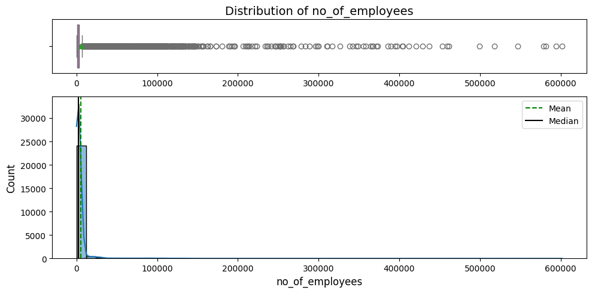

```python
# Distribution of number of employees
histogram_boxplot(data, "no_of_employees", kde=True, bins=50)
```

- The distribution is heavily right-skewed, with most values under 10,000 and a long tail of extreme outliers.
- Mean and median are both near zero, indicating most companies are small to mid-sized.
- The boxplot confirms many outliers, with some companies reporting over 600,000 employees.
- This skew may affect model performance and could require outlier handling.

#### Observations on Prevailing Wage

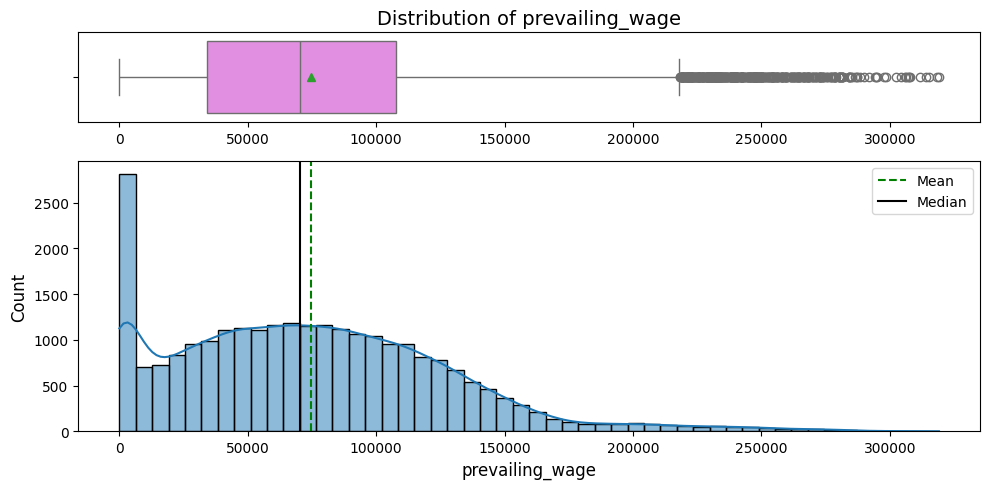

```python
# Distribution of prevailing wage
histogram_boxplot(data, "prevailing_wage", kde=True, bins=50)
```

- The distribution is right-skewed, with most wages under 100,000.
- The mean is pulled up by high-wage outliers, while the median remains lower.
- The boxplot shows many outliers above 200,000.
- A spike near zero may reflect unnormalized hourly wages and needs review.

#### Observations on Year of Establishment

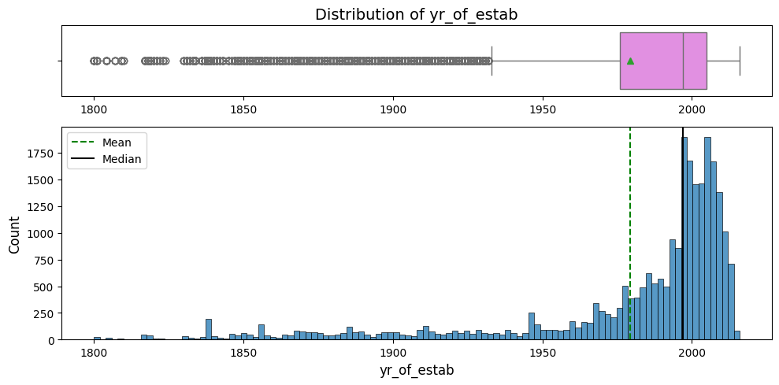

```python
# Distribution of year of establishment
histogram_boxplot(data, "yr_of_estab", kde=False)
```

- Most companies were established after 1980, with a spike in the early 2000s.
- A substantial number of older companies exist, especially before 1950, appearing as outliers on the lower end.
- The mean is slightly lower than the median, pulled left by these older values.
- While the feature is usable, very early entries (e.g., 1800s) may be irrelevant for modern visa application behaviors.

#### Observations on Education of Employee

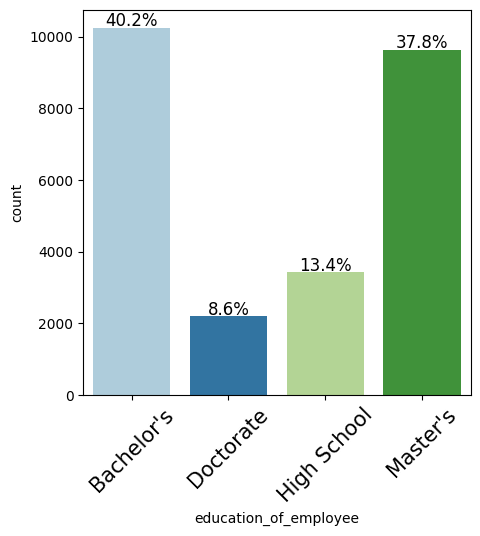

```python
labeled_barplot(data, "education_of_employee", perc=True)
```

- The majority of applicants hold either a Bachelor’s degree (40.2%) or a Master’s degree (37.8%), together accounting for nearly 80% of the total.
- Only 13.4% of applicants have a High School education, and just 8.6% hold a Doctorate.
- The distribution suggests the visa applicant pool is generally well-educated, with a strong concentration in mid-to-advanced academic qualifications.
- The bar plot suggests that most visa-sponsored jobs may not require PhDs.

#### Observations on Region of Employment

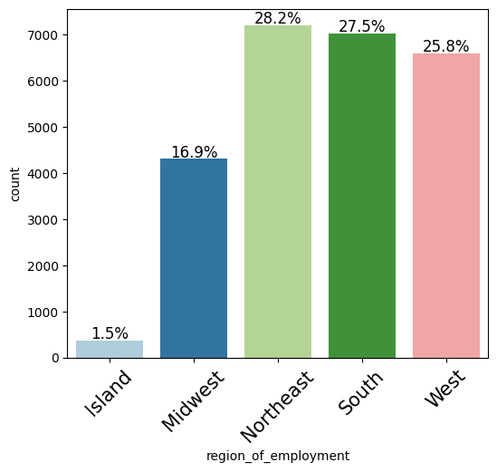

```python
# Observations on region of employment
labeled_barplot(data, "region_of_employment", perc=True)
```

- The majority of applicants seek employment in the Northeast (28.2%), South (27.5%), and West (25.8%) regions.
- The Midwest accounts for 16.9% of applications, making it the smallest among mainland regions.
- The Island region represents just 1.5% of applications, indicating limited demand in U.S. territories.

#### Observations on Job Experience

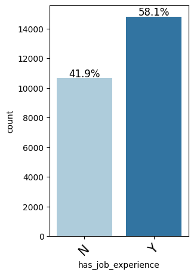

```python
# Observations on job experience
labeled_barplot(data, "has_job_experience", perc=True)
```

- The majority of applicants have prior job experience (58.1%), while 41.9% do not.

#### Observations on Case Status

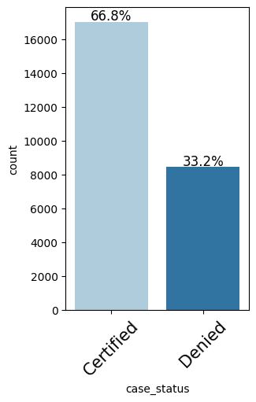

```python
# Observations on case status
labeled_barplot(data, "case_status", perc=True)
```

- The majority of visa applications are Certified (66.8%), while 33.2% are Denied.
- Although not severely imbalanced, the difference in class sizes suggests a moderate class imbalance.
- This should be addressed during model training to ensure the model does not become biased toward the majority class.